# POLS 3604

Lecture 7 | Representation

## Plan for Today

- Discuss constituencies

## Who are Constituents?

- Fenno (1977, 1978) details the different constituencies that members are responsive to
  - Geographic Constituency
    - All potential voters in a region
  - Electoral Supporters
    - Those who will vote for the member in elections
  - Primary Supporters
    - Those who will work for the member (go the extra mile!)
  - Candidate’s Inner Circle
    - Family, close friends, and advisers

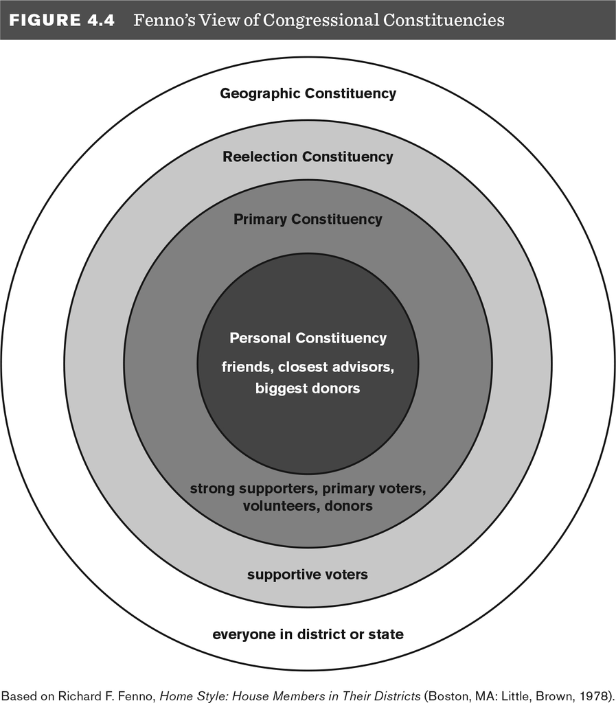

## The Ever Changing Geographic Constituency

- Generally, we think of the geographic constituency as the boundary that contains all people within a geographic area
- Elected officials tend to think of this geographic constituency as the area that contains not the total population, but rather the number of eligible voters
  - Basis of electoral accountability
- Therefore, geographic constituencies have changed dramatically over time
  - Initially, only white, mainly protestant, property owners could vote
    - We continue to see this division between the social elites and common person
  - Then none land owners, but gainfully employed white men could vote
  - Then voting rights are established in the Constitution with the 15th Amendment
    - Can’t deny anyone the right to vote based on the color of their skin
    - Unfortunately, the 15th Amendment only stipulates the conditions in which the right to vote cannot be denied, it does not cover other reasons that the right to vote could be denied
- Women are granted the right to vote in 1920
  - 19th Amendment
- The geographic constituency continues to change, especially in the South, during the Jim Crow Era
  - Poll tax, literacy tests, and other exclusionary practices
    - These restrictions are not based on race. Therefore, many white voters were disenfranchised
      - Grandfather Clauses
        - If your grandfather had the right to vote, then you did too
    - These restrictions are abolished with the 24th Amendment (1964) and the Voting Rights Act of 1965
- Lastly, the number of eligible voters was changed based on age
  - 26th Amendment (1971)

## National Representation

- Thinking outside of the concentric circles
- Members utilize their committee assignments and policy agendas to pursue national interests
  - Senators are more likely to have national constituencies
    - Fewer of them, more impact on policy, powerful committee assignments
- Policy focus
- Political ambition
  - Want to run for national offices (i.e., president)

## Substantive Representation

- Substance equals policy content
- Policy congruence
  - How well do a legislator’s issue or policy positions correspond to what their constituents want
- Voters can keep up with votes (public information)

## Descriptive Representation

- Do legislators “look” like their constituents?
- Many scholars argue that better descriptive representation leads to better substantive representation
- For example: do African American representatives provide better representation of African American interests
  - Research suggests, based on roll call voting, that this seems to be the case
    - Research on the Latino population is less developed, but the current research finds similar results

## Collective Representation

- The connection between Congress as a whole and the American public
- Does Congress reflect the wishes of the American public?

[figure not shown]

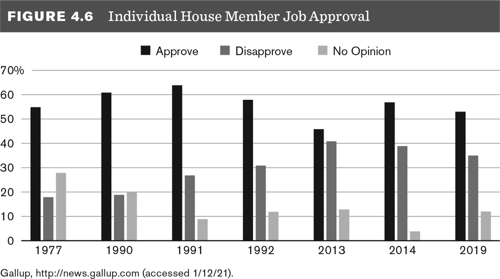

## Final Thoughts

- Elected officials focus on those people that are eligible voters
- The public disapproves of Congress as a whole, but largely approves of their own members

## What Do You Need to Do For Next Class?

- Read Chapter 5 TUSC
- Congressional Simulation - What’s Your Agenda?